# Introductory Workshop on Epidemiological and Statistical Analysis Using R

# Data wrangling

## Introduction

Remember, dataset contains data. Data contains variables in tabular format. There are:

- Variables in columns
- Observations in rows

Definition : Data are characteristics or information usually numerical that are collected through observation.Data is a set of values of qualitative or quantitative variables They are about one or more persons or objects, while a datum (singular of data) is single value of a single variable.

Definition : variable is any characteristics, number, or quantity that can be measured or counted.

Types of variables:

- Numeric
- Categorical

Categorical variables

- have values that describe a ‘quality’ or ‘characteristic’ of a data unit
- may be further described as ordinal or nominal
- such as an ordinal variable has values that can be logically ordered or ranked.
- Size : small, medium, large, extra large
- Attitudes : strongly agree, agree, disagree, strongly disagree

A nominal variable has no logical sequence. For example:

- Sex : male, female
- Business type : insurance, healthcare, retail
- Race : Asian, Caucasian, African

## Hands-on

### Data wrangling or transformation

Useful package

- **tidyverse** package is collection of packages, specifically the **dplyr** package. It is a very useful package to munge or wrangle or to tranform your data.

### Common procedures

The common procedures that data analyst does include:

1. reducing the size of dataset by selecting certain variables (or columns)
2. generating new variable from existing variables
3. sorting observation of a variable
4. grouping observations based on certain criteria
5. reducing variable to groups to in order to estimate summary statistic

### Some functions

1. `dplyr::select()` - to select a number of variables from a dataframe
2. `dplyr::mutate()` - to generate a new variable from existing variable
3. `dplyr::arrange()` - to sort observation of a variable
4. `dplyr::filter()` - to group observations that fulfill certain criteria
5. `dplyr::group_by()` and `dplyr::summarize()` - to reduce variable to groups in order to provide summary statistic

### Create a new project or set your working directory

This only applies if you work on RStudio IDE on your machine.

- It is very important to ensure you know where your working directory is
- To do so, the best practice is *is to create a new project*
- Create a RStudio project everytime you want to start new analysis (but not when you want redo them)

#### Create a new project

Steps:

1. File
2. New Project
3. New Directory
4. New Project
5. Choose Directory (folder)

The project directory is the directory (folder) where you store datasets, R codes and other outputs

#### Working directory

If you do not start with a new project, you still need to know **the location of your working directory?**.

1. to use R project to work with your data or analysis
2. if you are not using R project, make sure you are inside the correct working directory.
3. Type `getwd()` to display the active **working directory**. And to set a working directory use `setwd()`.
4. once you are know where your working directory is, you can start read or import data into your working directory.

### Packages to read data

- Remember, there are a number of packages you can use to read the data into R.
- It depends on the format of your data.
- Some useful packages to read data
  - **haven** package
  - **foreign** package
  - **readr** package
  - **readxl** package

### Data format

1. **readr** package provides a fast and friendly way to read rectangular data (like csv, tsv, and fwf).
2. **readxl** package reads .xls and .xlsx sheets.
3. **haven** package reads and writes SPSS, Stata, and SAS data.

### `starwars` data

Loading **tidyverse** packages will load **dplyr** automatically. If you want to load only **dplyr**, just type `library(dplyr)`.

```r
library(tidyverse)
```

Take a peek at the `starwars` data

```r
glimpse(starwars)
```

```
Rows: 87
Columns: 14
$ name       <chr> "Luke Skywalker", "C-3PO", "R2-D2", "Darth Vader", "Leia Or…
$ height     <int> 172, 167, 96, 202, 150, 178, 165, 97, 183, 182, 188, 180, 2…
$ mass       <dbl> 77.0, 75.0, 32.0, 136.0, 49.0, 120.0, 75.0, 32.0, 84.0, 77.…
$ hair_color <chr> "blond", NA, NA, "none", "brown", "brown, grey", "brown", N…
$ skin_color <chr> "fair", "gold", "white, blue", "white", "light", "light", "…
$ eye_color  <chr> "blue", "yellow", "red", "yellow", "brown", "blue", "blue",…
$ birth_year <dbl> 19.0, 112.0, 33.0, 41.9, 19.0, 52.0, 47.0, NA, 24.0, 57.0, …
$ sex        <chr> "male", "none", "none", "male", "female", "male", "female",…
$ gender     <chr> "masculine", "masculine", "masculine", "masculine", "femini…
$ homeworld  <chr> "Tatooine", "Tatooine", "Naboo", "Tatooine", "Alderaan", "T…
$ species    <chr> "Human", "Droid", "Droid", "Human", "Human", "Human", "Huma…
$ films      <list> <"The Empire Strikes Back", "Revenge of the Sith", "Return…
$ vehicles   <list> <"Snowspeeder", "Imperial Speeder Bike">, <>, <>, <>, "Imp…
$ starships  <list> <"X-wing", "Imperial shuttle">, <>, <>, "TIE Advanced x1",…
```

Next, we examine the first 10 observations of the data. There are 77 more rows NOT SHOWN. You can also see the types of the variables:

1. `chr` (character),
2. `int` (integer),
3. `dbl` (double)

### `dplyr::select()` , `dplyr::mutate()` and `dplyr::rename()`

1. name
2. height
3. mass
4. gender

```r
mysw <- starwars %>%
  select(name, gender, height, mass)
mysw
```

```
# A tibble: 87 × 4
   name               gender    height  mass
   <chr>              <chr>      <int> <dbl>
 1 Luke Skywalker     masculine    172    77
 2 C-3PO              masculine    167    75
 3 R2-D2              masculine     96    32
 4 Darth Vader        masculine    202   136
 5 Leia Organa        feminine     150    49
 6 Owen Lars          masculine    178   120
 7 Beru Whitesun lars feminine     165    75
 8 R5-D4              masculine     97    32
 9 Biggs Darklighter  masculine    183    84
10 Obi-Wan Kenobi     masculine    182    77
# ℹ 77 more rows
```

- The new dataset `mysw` is now created.
- You can see it in the `Environment` pane.

With `dplyr::mutate()`, you can generate new variable.

For example, in the dataset `mysw`, we want to create a new variable named as `bmi`.

This variable equals mass in kg divided by squared height (in meter)

$$bmi = \frac{kg}{m^2}$$

- Now, your dataset `mysw` has 5 columns (variables).
- The last variable is `bmi`

```r
mysw <- mysw %>%
  mutate(bmi = mass/(height/100)^2)
```

```r
mysw
```

```
# A tibble: 87 × 5
   name               gender    height  mass   bmi
   <chr>              <chr>      <int> <dbl> <dbl>
 1 Luke Skywalker     masculine    172    77  26.0
 2 C-3PO              masculine    167    75  26.9
 3 R2-D2              masculine     96    32  34.7
 4 Darth Vader        masculine    202   136  33.3
 5 Leia Organa        feminine     150    49  21.8
 6 Owen Lars          masculine    178   120  37.9
 7 Beru Whitesun lars feminine     165    75  27.5
 8 R5-D4              masculine     97    32  34.0
 9 Biggs Darklighter  masculine    183    84  25.1
10 Obi-Wan Kenobi     masculine    182    77  23.2
# ℹ 77 more rows
```

Now,

1. create a new variable *bmi2* which equals $bmi^2$.
2. rename *bmi2* to *bmisq*

```r
mysw <- mysw %>%
  mutate(bmi2 = bmi^2)
mysw <- mysw %>%
  rename(bmisq = bmi2)
```

```r
mysw
```

```
# A tibble: 87 × 6
   name               gender    height  mass   bmi bmisq
   <chr>              <chr>      <int> <dbl> <dbl> <dbl>
 1 Luke Skywalker     masculine    172    77  26.0  677.
 2 C-3PO              masculine    167    75  26.9  723.
 3 R2-D2              masculine     96    32  34.7 1206.
 4 Darth Vader        masculine    202   136  33.3 1111.
 5 Leia Organa        feminine     150    49  21.8  474.
 6 Owen Lars          masculine    178   120  37.9 1434.
 7 Beru Whitesun lars feminine     165    75  27.5  759.
 8 R5-D4              masculine     97    32  34.0 1157.
 9 Biggs Darklighter  masculine    183    84  25.1  629.
10 Obi-Wan Kenobi     masculine    182    77  23.2  540.
# ℹ 77 more rows
```

### `dplyr::arrange()`

This will sort the observation based on the values of the specified variable.

```r
mysw <- mysw %>%
  arrange(desc(bmi))
```

```r
mysw
```

```
# A tibble: 87 × 6
   name                  gender    height  mass   bmi   bmisq
   <chr>                 <chr>      <int> <dbl> <dbl>   <dbl>
 1 Jabba Desilijic Tiure masculine    175  1358 443.  196629.
 2 Dud Bolt              masculine     94    45  50.9   2594.
 3 Yoda                  masculine     66    17  39.0   1523.
 4 Owen Lars             masculine    178   120  37.9   1434.
 5 IG-88                 masculine    200   140  35     1225
 6 R2-D2                 masculine     96    32  34.7   1206.
 7 Grievous              masculine    216   159  34.1   1161.
 8 R5-D4                 masculine     97    32  34.0   1157.
 9 Jek Tono Porkins      masculine    180   110  34.0   1153.
10 Darth Vader           masculine    202   136  33.3   1111.
# ℹ 77 more rows
```

- Now, we will replace the dataset `mysw` with data that contain the `bmi`
- values from the lowest to the biggest bmi (ascending).

```r
mysw <- mysw %>%
  arrange(bmi)
```

```r
mysw
```

```
# A tibble: 87 × 6
   name          gender    height  mass   bmi bmisq
   <chr>         <chr>      <int> <dbl> <dbl> <dbl>
 1 Wat Tambor    masculine    193    48  12.9  166.
 2 Adi Gallia    feminine     184    50  14.8  218.
 3 Sly Moore     <NA>         178    48  15.1  230.
 4 Roos Tarpals  masculine    224    82  16.3  267.
 5 Padmé Amidala feminine     165    45  16.5  273.
 6 Lama Su       masculine    229    88  16.8  282.
 7 Jar Jar Binks masculine    196    66  17.2  295.
 8 Ayla Secura   feminine     178    55  17.4  301.
 9 Shaak Ti      feminine     178    57  18.0  324.
10 Barriss Offee feminine     166    50  18.1  329.
# ℹ 77 more rows
```

### `dplyr::filter()`

Here, we will create a new dataset (which we will name as `mysw_m_40`) that contains observations with these criteria:

- gender is male AND
- bmi at or above 40

```r
mysw_m_40 <- mysw %>%
  filter(gender == 'male', bmi >= 40)
mysw_m_40
```

```
# A tibble: 0 × 6
# ℹ 6 variables: name <chr>, gender <chr>, height <int>, mass <dbl>, bmi <dbl>,
#   bmisq <dbl>
```

Next, we will create a new dataset (named as `mysw_ht_45`) that contain

- `height` above 200 OR `BMI` above 45, AND
- does not include `NA` (which is missing value) observation for `bmi`

```r
mysw_ht_45 <- mysw %>%
  filter(height >200 | bmi >45, bmi != 'NA')
```

```r
mysw_ht_45
```

```
# A tibble: 9 × 6
  name                  gender    height  mass   bmi   bmisq
  <chr>                 <chr>      <int> <dbl> <dbl>   <dbl>
1 Roos Tarpals          masculine    224    82  16.3    267.
2 Lama Su               masculine    229    88  16.8    282.
3 Tion Medon            masculine    206    80  18.9    355.
4 Chewbacca             masculine    228   112  21.5    464.
5 Tarfful               masculine    234   136  24.8    617.
6 Darth Vader           masculine    202   136  33.3   1111.
7 Grievous              masculine    216   159  34.1   1161.
8 Dud Bolt              masculine     94    45  50.9   2594.
9 Jabba Desilijic Tiure masculine    175  1358 443.  196629.
```

### Categorize a numerical variable

```r
mysw <- mysw %>%
  mutate(cat_bmi = cut(bmi,
                       breaks = c(0, 20, 30, 50, 500),
                       labels = c('0-19', '20-29',
                                  '30-49', '50-500')))
```

```r
table(mysw$cat_bmi)
```

```
  0-19  20-29  30-49 50-500
    13     34     10      2
```

### Regroup a categorical variable

```r
mysw <- mysw %>%
  mutate(cat_bmi2 = recode(cat_bmi,
                           '0-19' = 'less than 30',
                           '20-29' = 'less than 30',
                           '30-49' = '30 or above',
                           '50-500' = '30 or above'))
```

```r
table(mysw$cat_bmi2)
```

```
less than 30  30 or above
          47           12
```

### More complicated **dplyr** verbs

To be more efficent, use multiple **dplyr** functions in one line of R code

- `select()`
- `group_by()`
- `summarize()`

Think of the results:

```r
desc_sw <- starwars %>%
  filter(sex == "male", height > 100, mass > 100) %>%
  select(height, mass, species) %>%
  group_by(species) %>%
  summarize(mean_ht = mean(height, na.rm = TRUE),
            mean_mass = mean(mass, na.rm = TRUE),
            freq = n())
```

The outputs

```r
desc_sw
```

```
# A tibble: 5 × 4
  species    mean_ht mean_mass  freq
  <chr>        <dbl>     <dbl> <int>
1 Besalisk      198        102     1
2 Human         187.       122     3
3 Kaleesh       216        159     1
4 Trandoshan    190        113     1
5 Wookiee       231        124     2
```

### References

1. **dplyr** [vignette](https://cran.r-project.org/web/packages/dplyr/vignettes/dplyr.html)
2. forcats package [here](http://r4ds.had.co.nz/factors.html)
3. reading data into R https://garthtarr.github.io/meatR/rio.html
4. a very good tutorial on **dplyr** at https://suzan.rbind.io/2018/01/dplyr-tutorial-1/

## Questions and Tips

- Whas is data wrangling?
- Why R store data in RAM?
- What are the common data wrangling processes in your field?
- What are R packages useful to wrangle data?
- If you are given a dataset in MS Excel, should you wrangle in Excel or in RStudio?
- Is data wrangling safe? Will it overwrite the original data?

# Epidemiological analysis

The workflow and codes for this section come largelyt from [The Epidemiologist R Handbook](https://epirhandbook.com/en/epidemic-curves.html)

## Objectives

We will generate an epidemic curve.

## Loading packages

Now, we will use a different function `pacman::p_load()`. This function will load the libraries. If the libraries are not installed, then they will be installed. But you have to be connected to the internet.

```r
pacman::p_load(
  rio,          # file import/export
  here,         # relative filepaths
  lubridate,    # working with dates/epiweeks
  aweek,        # alternative package for working with dates/epiweeks
  incidence2,   # epicurves of linelist data
  i2extras,     # supplement to incidence2
  stringr,      # search and manipulate character strings
  forcats,      # working with factors
  RColorBrewer, # Color palettes from colorbrewer2.org
  tidyverse     # data management + ggplot2 graphics
)
```

## Import data

We have a linelisting data.

```r
linelist <- import(here("datasets_wf", "linelist_cleaned.xlsx"))
glimpse(linelist)
```

```
Rows: 5,888
Columns: 30
$ case_id              <chr> "5fe599", "8689b7", "11f8ea", "b8812a", "893f25",…
$ generation           <dbl> 4, 4, 2, 3, 3, 3, 4, 4, 4, 4, 4, 4, 6, 5, 6, 9, 1…
$ date_infection       <dttm> 2014-05-08, NA, NA, 2014-05-04, 2014-05-18, 2014…
$ date_onset           <dttm> 2014-05-13, 2014-05-13, 2014-05-16, 2014-05-18, …
$ date_hospitalisation <dttm> 2014-05-15, 2014-05-14, 2014-05-18, 2014-05-20, …
$ date_outcome         <dttm> NA, 2014-05-18, 2014-05-30, NA, 2014-05-29, 2014…
$ outcome              <chr> NA, "Recover", "Recover", NA, "Recover", "Recover…
$ gender               <chr> "m", "f", "m", "f", "m", "f", "f", "f", "m", "f",…
$ age                  <dbl> 2, 3, 56, 18, 3, 16, 16, 0, 61, 27, 12, 42, 19, 7…
$ age_unit             <chr> "years", "years", "years", "years", "years", "yea…
$ age_years            <dbl> 2, 3, 56, 18, 3, 16, 16, 0, 61, 27, 12, 42, 19, 7…
$ age_cat              <chr> "0-4", "0-4", "50-69", "15-19", "0-4", "15-19", "…
$ age_cat5             <chr> "0-4", "0-4", "55-59", "15-19", "0-4", "15-19", "…
```

[output cut: 17 more lines]

## Aggregate data by hospitals

```r
count_data <- linelist %>%
  group_by(hospital, date_hospitalisation) %>%
  summarize(n_cases = n()) %>%
  filter(date_hospitalisation > as.Date("2013-06-01")) %>%
  ungroup()
count_data
```

```
# A tibble: 1,617 × 3
   hospital         date_hospitalisation n_cases
   <chr>            <dttm>                 <int>
 1 Central Hospital 2014-05-06 00:00:00        1
 2 Central Hospital 2014-05-10 00:00:00        1
 3 Central Hospital 2014-05-13 00:00:00        1
 4 Central Hospital 2014-05-28 00:00:00        2
 5 Central Hospital 2014-06-06 00:00:00        1
 6 Central Hospital 2014-06-09 00:00:00        1
 7 Central Hospital 2014-06-14 00:00:00        1
 8 Central Hospital 2014-06-19 00:00:00        1
 9 Central Hospital 2014-07-09 00:00:00        1
10 Central Hospital 2014-07-10 00:00:00        1
# ℹ 1,607 more rows
```

## Set date

We set the date to make sure we all have similar results. In reality, this is not so.

```r
data_date <- as.Date("2015-05-15")
```

## Generate epidemic curve

we will follow 2 steps and use the **incidence2** package:

1. Create an incidence object (using the function incidence())
- Provide the data
- Specify the date column to `date_index =`
- Specify the `interval =` into which the cases should be aggregated (daily, weekly, monthly..)
- Specify any grouping columns (e.g. gender, hospital, outcome)
2. Plot the incidence object
- Specify labels, colors, titles, etc.

```r
pacman::p_load(incidence2)
```

```r
# create the incidence object, aggregating cases by day
epi_day <- incidence(     # create incidence object
  x = linelist,             # dataset
  date_index = "date_onset",  # date column
  interval = "day"          # date grouping interval
  )
```

## Incidence format and data

This is the format of the incidence object.

```r
class(epi_day)
```

```
[1] "incidence2" "data.frame"
```

And this is the data that will form the curve

```r
epi_day
```

```
# incidence:  367 x 3
# count vars: date_onset
   date_index count_variable count
 * <date>     <chr>          <int>
 1 2014-04-07 date_onset         1
 2 2014-04-15 date_onset         1
 3 2014-04-21 date_onset         2
 4 2014-04-25 date_onset         1
 5 2014-04-26 date_onset         1
 6 2014-04-27 date_onset         1
 7 2014-05-01 date_onset         2
 8 2014-05-03 date_onset         1
 9 2014-05-04 date_onset         1
10 2014-05-05 date_onset         1
# ℹ 357 more rows
```

or

```r
summary(epi_day)
```

```
From:          2014-04-07
To:            2015-04-30
Groups:

Total observations:
# A data frame: 1 × 2
  count_variable count
  <chr>          <int>
1 date_onset      5632
```

## Plot epidemic curve

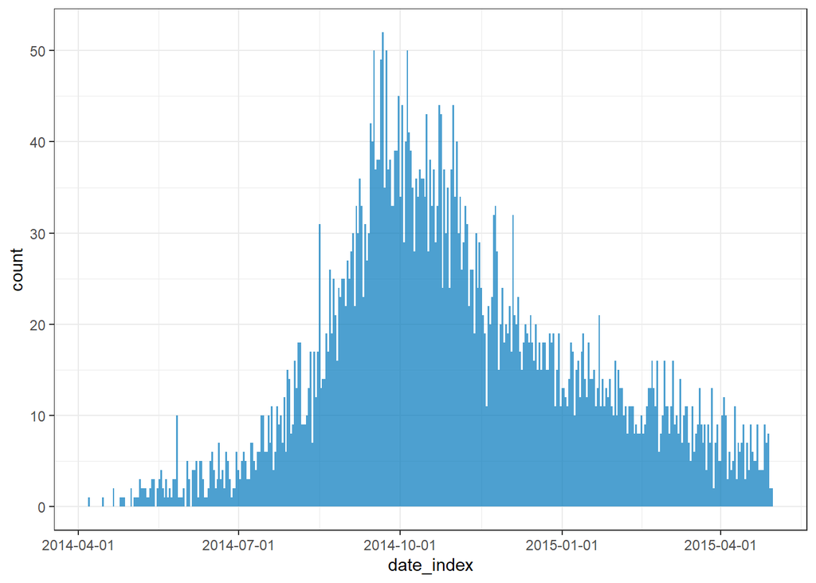

```r
plot(epi_day)
```

# Statistical modelling: Scalar or continuous outcome (20 minutes)

## Introduction

Objectives:

At the end of this section, you will be to

- model continuous outcome variable using multiple linear regression
- perform model assessment
- interpret model

Regression analysis helps us

- to explain relationship between variables
- to estimate the effect of a set of variables (predictors) onto another variable (the outcome)
- to make inference – how large the effect?
- to predict the outcome based on new data

Estimation and inference are different.

- To estimate: A process by which one makes inferences about a population, based on information obtained from a sample.
- To infer : To make reasons involved in drawing a conclusion or making a logical judgment on the basis of circumstantial evidence and prior conclusions and not only on the basis of direct observation

## Hands-on

### Objectives

In this short practicals, we will show how to perform estimation, inference, prediction and model checking for linear regression model.

Steps:

- Create project
- Make sure dataset is(are) inside the project directory
- load required R libraries

```r
library(tidyverse) #data wrangling and data visualization
library(haven) #read statistical data
library(here) #help locate the working directory
library(broom) #tidier results
```

First, we read the data into R.

```r
data0 <- read_dta(here('datasets_wf', 'datamssm_a.dta'))
glimpse(data0)
```

```
Rows: 4,340
Columns: 21
$ codesub  <chr> "R-S615112", "MAA615089", "M-M616372", "MFM615361", "R-A61578…
$ age      <dbl> 70, 20, 29, 25, 37, 43, 26, 28, 48, 20, 56, 55, 26, 39, 18, 2…
$ hpt      <dbl+lbl> 1, 0, 0, 0, 0, 0, 0, 0, 0, 0, 1, 0, 0, 0, 0, 0, 0, 0, 0, …
$ smoking  <dbl+lbl> 3, 1, 3, 1, 3, 3, 3, 3, 1, 3, 3, 3, 3, 3, 3, 3, 3, 3, 1, …
$ dmdx     <dbl+lbl> 0, 0, 0, 0, 0, 0, 0, 0, 0, 0, 0, 0, 0, 0, 0, 0, 0, 0, 0, …
$ height   <dbl> 1.54, 1.74, 1.54, 1.60, 1.44, 1.46, 1.47, 1.61, 1.68, 1.55, 1…
$ weight   <dbl> 40.0, 54.6, 37.0, 48.4, 44.5, 45.5, 48.0, 40.0, 48.4, 41.0, 5…
$ waist    <dbl> 76.0, 83.0, 83.0, 83.5, 85.0, 90.0, 91.0, 80.0, 82.0, 79.0, 9…
$ hip      <dbl> 61, 62, 63, 64, 64, 64, 64, 64, 65, 66, 67, 67, 67, 67, 67, 6…
$ msbpr    <dbl> 135.0, 105.0, 91.0, 117.0, 102.0, 124.0, 120.0, 85.0, 112.0, …
$ mdbpr    <dbl> 80.0, 58.0, 60.0, 68.5, 78.0, 65.5, 77.0, 60.0, 74.0, 52.0, 1…
$ hba1c    <dbl> 5.2, 5.3, 4.8, 4.8, 5.1, 5.1, 4.8, 4.9, 5.6, 4.2, 5.1, 5.3, 4…
$ fbs      <dbl> 3.99, 4.26, 4.94, 4.60, 4.60, 4.42, 3.82, 4.40, 4.80, 3.68, 6…
$ mogtt1h  <dbl> 7.06, 8.63, 6.26, 4.31, 9.49, 6.29, NA, 6.43, 9.23, 6.70, 8.7…
$ mogtt2h  <dbl> 3.22, 6.49, 5.15, 3.85, 7.71, 5.65, 5.88, 4.89, 4.29, 2.59, 7…
$ totchol  <dbl> 5.43, 5.13, 5.55, 4.01, 5.21, 6.19, 4.33, 5.84, 6.14, 6.02, 6…
$ ftrigliz <dbl> 1.06, 1.17, 0.72, 1.12, 0.78, 1.11, 0.73, 0.79, 1.63, 0.81, 1…
$ hdl      <dbl> 1.65, 1.59, 2.24, 1.21, 1.43, 2.18, 0.98, 1.81, 1.63, 1.47, 1…
$ ldl      <dbl> 2.69, 2.79, 2.55, 1.83, 2.40, 2.93, 1.82, 3.43, 3.71, 2.77, 3…
$ gender   <dbl+lbl> 0, 1, 0, 1, 0, 0, 0, 0, 1, 0, 0, 0, 0, 0, 0, 0, 0, 0, 1, …
$ crural   <dbl+lbl> 1, 1, 1, 1, 1, 1, 1, 1, 1, 1, 1, 1, 0, 1, 0, 1, 1, 0, 1, …
```

Convert labelled variables to factor variables:

```r
data0 <- data0 %>%
  mutate_if(is.labelled, ~as_factor(.))
summary(data0)
```

```
   codesub               age         hpt                  smoking
 Length:4340        Min.   :18.00   no :3836   still smoking  : 698
 Class :character   1st Qu.:38.00   yes: 504   quitted smoking: 335
 Mode  :character   Median :48.00              never smoked   :3307
                    Mean   :47.84
                    3rd Qu.:58.00
                    Max.   :89.00

  dmdx          height          weight           waist             hip
 no :3870   Min.   :1.270   Min.   : 30.00   Min.   : 50.80   Min.   : 61.00
 yes: 470   1st Qu.:1.510   1st Qu.: 53.80   1st Qu.: 77.00   1st Qu.: 91.00
            Median :1.560   Median : 62.00   Median : 86.00   Median : 97.00
            Mean   :1.568   Mean   : 63.75   Mean   : 86.32   Mean   : 97.88
            3rd Qu.:1.630   3rd Qu.: 71.97   3rd Qu.: 95.00   3rd Qu.:104.00
            Max.   :1.960   Max.   :187.80   Max.   :154.50   Max.   :160.00
            NA's   :1       NA's   :2        NA's   :2        NA's   :2
     msbpr           mdbpr            hba1c             fbs
 Min.   : 68.5   Min.   : 41.50   Min.   : 0.200   Min.   : 2.500
 1st Qu.:117.0   1st Qu.: 70.00   1st Qu.: 5.100   1st Qu.: 4.480
 Median :130.0   Median : 77.50   Median : 5.400   Median : 5.180
 Mean   :133.5   Mean   : 78.47   Mean   : 5.805   Mean   : 5.734
 3rd Qu.:146.5   3rd Qu.: 86.00   3rd Qu.: 5.800   3rd Qu.: 6.020
 Max.   :237.0   Max.   :128.50   Max.   :15.000   Max.   :28.010
                                  NA's   :70       NA's   :248
    mogtt1h          mogtt2h          totchol          ftrigliz
 Min.   : 0.160   Min.   : 0.160   Min.   : 0.180   Min.   : 0.110
 1st Qu.: 6.540   1st Qu.: 5.150   1st Qu.: 4.970   1st Qu.: 0.930
 Median : 8.590   Median : 6.600   Median : 5.700   Median : 1.260
 Mean   : 9.106   Mean   : 7.343   Mean   : 5.792   Mean   : 1.534
 3rd Qu.:10.840   3rd Qu.: 8.410   3rd Qu.: 6.530   3rd Qu.: 1.770
 Max.   :41.500   Max.   :37.370   Max.   :23.140   Max.   :12.660
 NA's   :604      NA's   :608      NA's   :54       NA's   :53
      hdl             ldl            gender       crural
 Min.   :0.080   Min.   : 0.140   female:2817   urban:2218
 1st Qu.:1.110   1st Qu.: 2.790   male  :1523   rural:2122
 Median :1.320   Median : 3.460
 Mean   :1.345   Mean   : 3.549
 3rd Qu.:1.540   3rd Qu.: 4.245
 Max.   :4.430   Max.   :10.560
 NA's   :52      NA's   :53
```

### Estimation

Now, we let’s estimate a multivariable (two or more predictors) model with

- One dependent variable - `hba1c`
- Two covariates : `ldl` and `gender`

```r
modldl.gender <- lm(hba1c ~ ldl + gender, data = data0)
summary(modldl.gender)
```

```
Call:
lm(formula = hba1c ~ ldl + gender, data = data0)

Residuals:
    Min      1Q  Median      3Q     Max
-5.7168 -0.6644 -0.3759  0.0068  8.9088

Coefficients:
            Estimate Std. Error t value Pr(>|t|)
(Intercept)  5.07444    0.07426  68.332   <2e-16 ***
ldl          0.20134    0.01946  10.349   <2e-16 ***
gendermale   0.04100    0.04583   0.895    0.371
---
Signif. codes:  0 '***' 0.001 '**' 0.01 '*' 0.05 '.' 0.1 ' ' 1

Residual standard error: 1.428 on 4262 degrees of freedom
  (75 observations deleted due to missingness)
Multiple R-squared:  0.02468,   Adjusted R-squared:  0.02422
F-statistic: 53.92 on 2 and 4262 DF,  p-value: < 2.2e-16
```

And now multivariable with interaction. We add a new covariate which is the product of two covariates:

- Dependent variable hba1c
- Covariates: `ldl + gender + ldl*gender`

```r
modldl.gender.ia <- lm(hba1c ~ ldl + gender + ldl*gender, data = data0)
summary(modldl.gender.ia)
```

```
Call:
lm(formula = hba1c ~ ldl + gender + ldl * gender, data = data0)

Residuals:
    Min      1Q  Median      3Q     Max
-5.7152 -0.6641 -0.3759  0.0076  8.9058

Coefficients:
                Estimate Std. Error t value Pr(>|t|)
(Intercept)     5.067460   0.089424  56.668   <2e-16 ***
ldl             0.203310   0.023982   8.478   <2e-16 ***
gendermale      0.061427   0.152657   0.402    0.687
ldl:gendermale -0.005754   0.041028  -0.140    0.888
---
Signif. codes:  0 '***' 0.001 '**' 0.01 '*' 0.05 '.' 0.1 ' ' 1

Residual standard error: 1.428 on 4261 degrees of freedom
  (75 observations deleted due to missingness)
Multiple R-squared:  0.02468,   Adjusted R-squared:  0.024
F-statistic: 35.95 on 3 and 4261 DF,  p-value: < 2.2e-16
```

### Inference

Getting the $95\%$ for the $\hat{\beta}$

```r
confint(modldl.gender)
```

```
                  2.5 %    97.5 %
(Intercept)  4.92885330 5.2200367
ldl          0.16319979 0.2394882
gendermale  -0.04884214 0.1308511
```

```r
confint(modldl.gender.ia)
```

```
                     2.5 %     97.5 %
(Intercept)     4.89214200 5.24277734
ldl             0.15629309 0.25032698
gendermale     -0.23785925 0.36071345
ldl:gendermale -0.08619124 0.07468261
```

Nicer results with `broom::tidy()`

```r
res1 <- tidy(modldl.gender, conf.int = TRUE)
res1
```

```
# A tibble: 3 × 7
  term        estimate std.error statistic  p.value conf.low conf.high
  <chr>          <dbl>     <dbl>     <dbl>    <dbl>    <dbl>     <dbl>
1 (Intercept)   5.07      0.0743    68.3   0          4.93       5.22
2 ldl           0.201     0.0195    10.3   8.33e-25   0.163      0.239
3 gendermale    0.0410    0.0458     0.895 3.71e- 1  -0.0488     0.131
```

We can save the result in `csv` format for easy editing.

```r
res2 <- tidy(modldl.gender.ia)
write_csv(res2, 'results_linear.csv')
```

### Prediction

Now, we can get the fitted values for hba1c

```r
augment(modldl.gender.ia) %>% tail()
```

```
# A tibble: 6 × 10
  .rownames hba1c   ldl gender .fitted  .resid    .hat .sigma .cooksd .std.resid
  <chr>     <dbl> <dbl> <fct>    <dbl>   <dbl>   <dbl>  <dbl>   <dbl>      <dbl>
1 4335        5.8  3.92 female    5.86 -0.0644 3.99e-4   1.43 2.03e-7    -0.0451
2 4336        7.9  4.53 male      6.02  1.88   1.19e-3   1.43 5.16e-4     1.31
3 4337        5.3  3    male      5.72 -0.422  8.32e-4   1.43 1.81e-5    -0.295
4 4338        6    4.24 female    5.93  0.0705 4.94e-4   1.43 3.01e-7     0.0494
5 4339        9.5  4.25 female    5.93  3.57   4.98e-4   1.43 7.78e-4     2.50
6 4340       10.2  2.54 male      5.63  4.57   1.22e-3   1.43 3.13e-3     3.20
```

### Model checking

We need to check for linear model assumptions

1. Linearity of residuals
2. Residuals are normally distributed
3. Equal variance of residuals
4. Independence observations

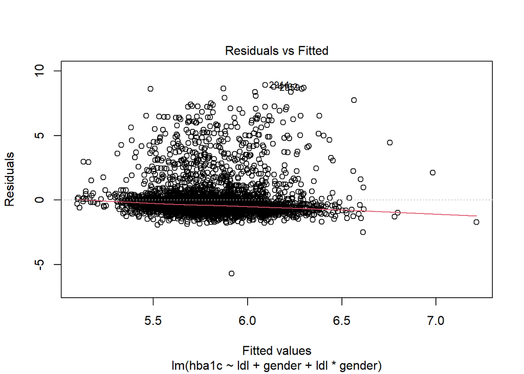

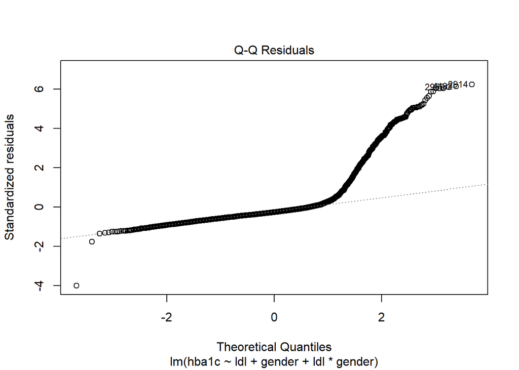

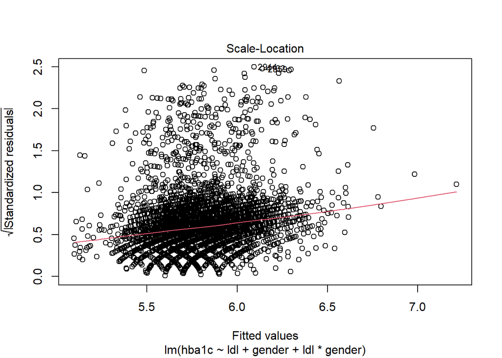

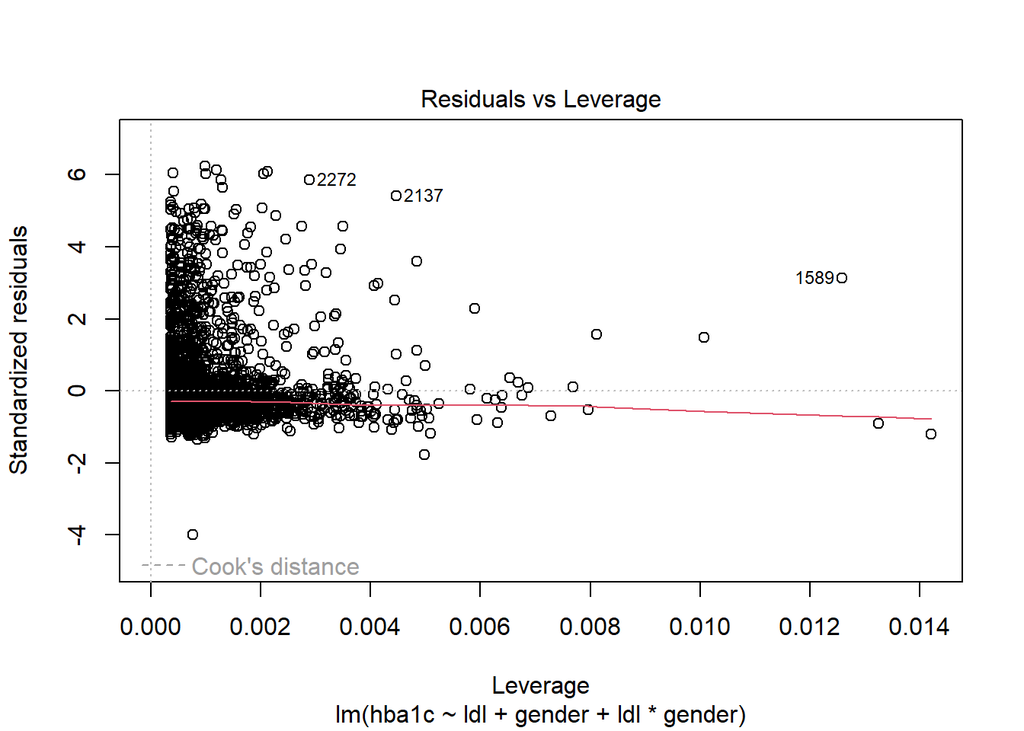

```r
plot(modldl.gender.ia)
```

Somethings are not right

- does not look random
- some outliers
- is it linear?

We need to do further treatment:

- transformation of variables
- more complex model
- removing of influential observations

## Questions and Tips

- what function did we use to estimate a `lm` model?
- what is another function we can use?
- Model specification is important
- Which variables are
  - confounders
  - mediators
  - moderators
- Effect of multicolinearity
- Model checking and model assessment
- Are there outliers and are they influentials?
- Simple model vs complex model, which will you prioritize?
- Bias and variance
- Exploratory vs Confirmatory model

# Statistical modelling: Binary outcome (20 minutes)

## Motivation

When outcome is binary, the common analysis for making inference or prediction is logistic regression.

What are the aims?

- To explain vs to predict
- In statistics, to explain is more common: Interested in the beta
- In analytics, to predict is more common: Not interested in beta, but interested to predict the outcome

Questions:

- Give example of outcome relevant to your area that you may study
- State the objective of the analysis
- Are the data suitable for logistic regression analysis?

When the outcome is categorical (in the form of binary), we model using logistic regression. Examples of binary outcome

- Acceptance of loan = Accepted vs Rejected
- Loan defaulters = Yes vs No

Binary logistic regression models, for example :

- Acceptance of loan <- gender + age + job status + ….
- Loan defaulters <- age + income + amount of loan + …..

The logit model is written as:

$$log \frac{p}{1-p} = \beta_0 + \beta_{age} + \beta_{male} + \beta_{chinese} + \beta_{indians} + \beta_{age}\times\beta_{male}$$

## Hands-on

### Load packages

```r
library(tidyverse)
library(readxl)
library(here)
library(broom)
```

### Read data

The data comes from a surgeon (Dr Najmi). The data contains variables from patients with peptic ulcer disease.

It is in excel form.

```r
PUP2 <- read_excel(here('datasets_wf',
                        'PUP2.xlsx'))
```

Quickly examine types of variables and summary statistics:

```r
glimpse(PUP2)
```

```
Rows: 121
Columns: 23
$ no                  <dbl> 105, 107, 94, 103, 109, 111, 79, 85, 88, 89, 100, …
$ age                 <dbl> 42, 66, 67, 19, 77, 39, 62, 71, 69, 97, 52, 21, 57…
$ gender              <chr> "male", "female", "male", "male", "male", "male", …
$ epigastric_pain     <chr> "yes", "yes", "yes", "yes", "yes", "yes", "yes", "…
$ onset_more_24_hrs   <chr> "no", "no", "no", "yes", "yes", "yes", "yes", "no"…
$ diabetes            <chr> "no", "no", "no", "no", "no", "no", "yes", "no", "…
$ NSAIDS              <chr> "no", "no", "yes", "no", "no", "no", "no", "no", "…
$ previous_OGDS       <chr> "no", "no", "no", "yes", "no", "no", "no", "no", "…
$ ASA                 <dbl> 1, 1, 1, 1, 2, 1, 2, 2, 1, 1, 2, 1, 2, 1, 1, 2, 2,…
$ systolic            <dbl> 141, 197, 126, 90, 147, 115, 103, 159, 145, 105, 1…
$ diastolic           <dbl> 98, 88, 73, 40, 82, 86, 55, 68, 75, 65, 74, 50, 86…
$ tenderness          <chr> "generalized", "generalized", "generalized", "loca…
$ guarding            <chr> "yes", "yes", "yes", "yes", "no", "yes", "yes", "n…
$ hemoglobin          <dbl> 18.0, 12.0, 12.0, 12.0, 11.0, 18.0, 8.1, 13.3, 11.…
$ twc                 <dbl> 6.0, 6.0, 13.0, 20.0, 21.0, 4.0, 5.0, 12.0, 6.0, 2…
$ platelet            <dbl> 415, 292, 201, 432, 324, 260, 461, 210, 293, 592, …
$ PULP                <dbl> 2, 3, 3, 2, 7, 1, 2, 5, 3, 4, 2, 3, 4, 3, 5, 5, 1,…
$ admission_to_op_hrs <dbl> 2, 2, 3, 3, 3, 3, 4, 4, 4, 4, 4, 5, 5, 6, 6, 6, 6,…
$ perforation         <dbl> 0.5, 1.0, 0.5, 0.5, 1.0, 1.0, 3.0, 1.5, 0.5, 1.5, …
$ degree_perforation  <chr> "small", "small", "small", "small", "small", "smal…
$ SSSI                <chr> "no", "no", "no", "no", "no", "no", "no", "no", "n…
$ sepsis              <chr> "no", "no", "no", "no", "no", "no", "yes", "no", "…
$ outcome             <chr> "alive", "alive", "alive", "alive", "alive", "aliv…
```

Data summary:

```r
summary(PUP2)
```

```
       no           age           gender          epigastric_pain
 Min.   :  1   Min.   :19.00   Length:121         Length:121
 1st Qu.: 31   1st Qu.:49.00   Class :character   Class :character
 Median : 61   Median :64.00   Mode  :character   Mode  :character
 Mean   : 61   Mean   :60.43
 3rd Qu.: 91   3rd Qu.:75.00
 Max.   :121   Max.   :97.00
 onset_more_24_hrs    diabetes            NSAIDS          previous_OGDS
 Length:121         Length:121         Length:121         Length:121
 Class :character   Class :character   Class :character   Class :character
 Mode  :character   Mode  :character   Mode  :character   Mode  :character



      ASA           systolic       diastolic       tenderness
 Min.   :1.000   Min.   : 67.0   Min.   : 38.00   Length:121
 1st Qu.:1.000   1st Qu.:112.0   1st Qu.: 63.00   Class :character
 Median :1.000   Median :128.0   Median : 71.00   Mode  :character
 Mean   :1.545   Mean   :128.6   Mean   : 72.07
 3rd Qu.:2.000   3rd Qu.:143.0   3rd Qu.: 81.00
 Max.   :3.000   Max.   :197.0   Max.   :116.00
   guarding           hemoglobin         twc           platelet
 Length:121         Min.   : 3.30   Min.   : 2.00   Min.   : 11.0
 Class :character   1st Qu.:10.00   1st Qu.: 9.00   1st Qu.:224.0
 Mode  :character   Median :12.00   Median :12.00   Median :308.0
                    Mean   :12.32   Mean   :13.03   Mean   :314.4
                    3rd Qu.:15.00   3rd Qu.:16.00   3rd Qu.:392.0
                    Max.   :19.40   Max.   :37.00   Max.   :798.0
      PULP       admission_to_op_hrs  perforation    degree_perforation
 Min.   :0.000   Min.   : 1.00       Min.   :0.300   Length:121
 1st Qu.:2.000   1st Qu.: 5.00       1st Qu.:0.500   Class :character
 Median :3.000   Median : 8.00       Median :1.000   Mode  :character
 Mean   :3.529   Mean   :10.07       Mean   :1.225
 3rd Qu.:5.000   3rd Qu.:12.00       3rd Qu.:1.500
 Max.   :9.000   Max.   :72.00       Max.   :5.000
     SSSI              sepsis            outcome
 Length:121         Length:121         Length:121
 Class :character   Class :character   Class :character
 Mode  :character   Mode  :character   Mode  :character
```

We convert the variable outcome from character to factor

```r
PUP2 <- PUP2 %>%
  mutate(oc2 = factor(outcome))
```

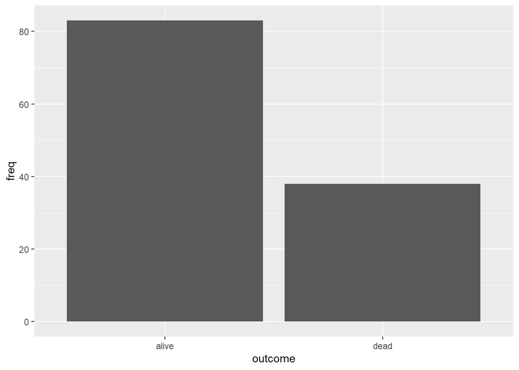

```r
PUP2 %>%
  ggplot(aes(x = oc2)) +
  geom_bar() +
  xlab('outcome') + ylab('freq')
```

### Multivariables logistic regression

Let us run a multivariable model with

- Outcome: oc2
- Primary variables: ASA, degree of perforation, PULP, NSAIDS, Hg, onset more than 24
- Confounding variables: age, gender, diabetes

Primary variables are variables of interest that would predict outcome of peptic ulcer. Confounding variables are variables that may alter the effect of the primary variables when they are in the model. This may happen due to different distribution of them at the beginning of the study.

Only control baseline variables (refer to Andrew Gelman argument)

```r
model_multivar <- glm(oc2 ~ age + gender + epigastric_pain +
                        onset_more_24_hrs + diabetes + NSAIDS +
                        factor(ASA) + PULP + perforation + hemoglobin,
                      family = binomial(link = 'logit'),
                      data = PUP2)
```

Let’s view in a tidy format:

```r
tidy(model_multivar, conf.int = T)
```

```
# A tibble: 12 × 7
   term                  estimate std.error statistic p.value conf.low conf.high
   <chr>                    <dbl>     <dbl>     <dbl>   <dbl>    <dbl>     <dbl>
 1 (Intercept)           -3.77e+0    2.26    -1.67    9.48e-2  -8.54      0.463
 2 age                    4.31e-5    0.0206   0.00209 9.98e-1  -0.0408    0.0410
 3 gendermale            -8.33e-1    0.593   -1.40    1.60e-1  -2.02      0.326
 4 epigastric_painyes     5.37e-1    1.26     0.426   6.70e-1  -1.68      3.68
 5 onset_more_24_hrsyes   1.54e-1    0.516    0.298   7.65e-1  -0.859     1.18
 6 diabetesyes            5.98e-3    0.687    0.00869 9.93e-1  -1.37      1.35
 7 NSAIDSyes              2.91e-1    0.488    0.596   5.51e-1  -0.683     1.24
 8 factor(ASA)2           7.62e-1    0.599    1.27    2.03e-1  -0.401     1.97
 9 factor(ASA)3          -9.45e-2    1.18    -0.0799  9.36e-1  -2.63      2.12
10 PULP                   7.50e-2    0.168    0.446   6.56e-1  -0.256     0.409
11 perforation            1.12e+0    0.332    3.39    7.11e-4   0.522     1.82
12 hemoglobin             6.83e-2    0.0827   0.826   4.09e-1  -0.0942    0.233
```

Let add an interaction term, assuming that the effect of covariates on outcome maybe different according to different level of PULP and extent of perforation size. So the interaction effect is between perforation and PULP.

```r
model_ia <- glm(oc2 ~ age + gender + epigastric_pain +
                  onset_more_24_hrs + diabetes + NSAIDS +
                  factor(ASA) + PULP + perforation +
                  hemoglobin + perforation:PULP,
                family = binomial(link = 'logit'), data = PUP2)
```

Then store as a tidy object

```r
model_ia <- tidy(model_ia, conf.int = T)
```

And now we export the table in csv format for easy manipulation in MS Excel for example:

```r
write_csv(model_ia, 'model_ia.csv')
```

### Model checking

Making predictions

- log-odds
- probability

```r
fitted_logodds <- augment(model_multivar, type.predict = 'link')
fitted_prob <- augment(model_multivar, type.predict = 'response')
```

Let’s see the results

```r
fitted_logodds
```

```
# A tibble: 121 × 17
   oc2     age gender epigastric_pain onset_more_24_hrs diabetes NSAIDS
   <fct> <dbl> <chr>  <chr>           <chr>             <chr>    <chr>
 1 alive    42 male   yes             no                no       no
 2 alive    66 female yes             no                no       no
 3 alive    67 male   yes             no                no       yes
 4 alive    19 male   yes             yes               no       no
 5 alive    77 male   yes             yes               no       no
 6 alive    39 male   yes             yes               no       no
 7 dead     62 female yes             yes               yes      no
 8 alive    71 female yes             no                no       no
 9 alive    69 male   yes             no                yes      yes
10 alive    97 female yes             yes               no       yes
# ℹ 111 more rows
# ℹ 10 more variables: `factor(ASA)` <fct>, PULP <dbl>, perforation <dbl>,
#   hemoglobin <dbl>, .fitted <dbl>, .resid <dbl>, .hat <dbl>, .sigma <dbl>,
#   .cooksd <dbl>, .std.resid <dbl>
```

```r
fitted_prob
```

```
# A tibble: 121 × 17
   oc2     age gender epigastric_pain onset_more_24_hrs diabetes NSAIDS
   <fct> <dbl> <chr>  <chr>           <chr>             <chr>    <chr>
 1 alive    42 male   yes             no                no       no
 2 alive    66 female yes             no                no       no
 3 alive    67 male   yes             no                no       yes
 4 alive    19 male   yes             yes               no       no
 5 alive    77 male   yes             yes               no       no
 6 alive    39 male   yes             yes               no       no
 7 dead     62 female yes             yes               yes      no
 8 alive    71 female yes             no                no       no
 9 alive    69 male   yes             no                yes      yes
10 alive    97 female yes             yes               no       yes
# ℹ 111 more rows
# ℹ 10 more variables: `factor(ASA)` <fct>, PULP <dbl>, perforation <dbl>,
#   hemoglobin <dbl>, .fitted <dbl>, .resid <dbl>, .hat <dbl>, .sigma <dbl>,
#   .cooksd <dbl>, .std.resid <dbl>
```

## Questions and Tips

- What function did we use to perform logistic regression?
- What statistical framework did we use to perform the logistic regression? What statistical family did we choose for estimation?
- How to assess logistic regression model?
  - confusion matrix
  - overall model fitness (Hosmer Lemeshow test)
  - Area under the ROC curve
- Model diagnostics for outliers and influential cases

# Summary

Useful for users and trainers:

1. Draft your data analysis workflow
2. Identify each stage of the workflow
3. At each stage, ask
- what task is involved
- what **R functions** required to perform the task
- which **R package that contains the function**
4. Perform the task using the default parameters
5. Tweak the function to suit more complex task
6. If errors committed, get help
- friends
- StackOverflow
- R community
7. Use tools
- Posit Cloud
- RStudio IDE
- Google Collab
8. Traditional stat software may not able to handle the demand of modern-wide-big-on-the-cloud data
9. Practice, practice, practise

## ALL THE BEST

[figure not shown]